# ARIBA

https://github.com/sanger-pathogens/ariba/wiki

### Methods:

1. Reference sequences in the AMR database are clustered by similarity using **CD-HIT**
2. Reads are mapped to the reference sequences using **minimap** (we obtain a set of reads per reference cluster)
3. The reads for each reference cluster are assembled independently using **fermi-lite**: we obtain contigs/assemblies
4. The closest reference sequence to the obtained contigs is identified **nucmer**
5. The contigs are compared to the reference sequence to identify variants (SNPs) **nucmer**
6. The reads for each reference cluster are mapped to the contigs **Bowtie2** and variants are identified using **SAMtools**

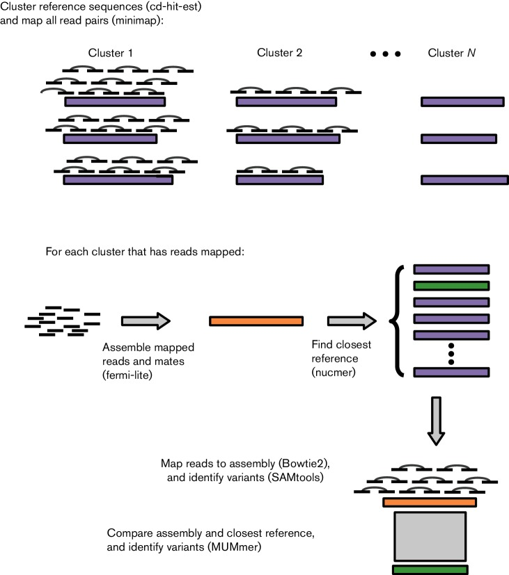

### 1. getref:

**ariba getref card out.card**  
*generates files out.card.fa out.card.log out.card.tsv in current directory*

out.card.tsv. Metadata de base de datos CARD: 7014 entradas: 2934 unicas  
out.card.fa Secuencias de base de datos CARD: 2934 secuencias

```r
library(readr)
library(knitr)
library(dplyr)
out_card <- read_delim("/home/erubio/Documentos/UOCMaster/ARIBA/out.card.tsv",
    "\t", escape_double = FALSE, col_names = FALSE,
    trim_ws = TRUE)
kable(head(out_card, n=20L))
```

| X1 | X2 | X3 | X4 | X5 | X6 |
| --- | --- | --- | --- | --- | --- |
| PDC-4.3002501.FJ666067.0-1194.1619 | 1 | 0 | . | . | PDC-4 |
| PDC-4.3002501.FJ666067.0-1194.1619 | 1 | 0 | . | . | b’PDC-4 is a extended-spectrum beta-lactamase found in Pseudomonas aeruginosa.’ |
| CblA-1.3002999.GQ343019.132-1023.1188 | 1 | 0 | . | . | CblA-1 |
| CblA-1.3002999.GQ343019.132-1023.1188 | 1 | 0 | . | . | b’CblA-1 beta-lactamase is a class A beta-lactamase found in Bacteroides uniformis that is species-specific.’ |
| ompF.3003390.U00096.3.985893-986982.5413 | 1 | 1 | . | . | Escherichia coli ompF with mutation conferring resistance to beta-lactam antibiotics |
| ompF.3003390.U00096.3.985893-986982.5413 | 1 | 1 | R154A | . | b’The Escherichia coli ompF (oprF) is a nonspecific porin channel involved in the membrane translocation of small hydrophilic molecules, including and especially beta-lactam antibiotics. Mutations in … |
| ompF.3003390.U00096.3.985893-986982.5413 | 1 | 1 | G141D | . | b’The Escherichia coli ompF (oprF) is a nonspecific porin channel involved in the membrane translocation of small hydrophilic molecules, including and especially beta-lactam antibiotics. Mutations in … |
| ompF.3003390.U00096.3.985893-986982.5413 | 1 | 1 | R154D | . | b’The Escherichia coli ompF (oprF) is a nonspecific porin channel involved in the membrane translocation of small hydrophilic molecules, including and especially beta-lactam antibiotics. Mutations in … |
| ompF.3003390.U00096.3.985893-986982.5413 | 1 | 1 | G141E | . | b’The Escherichia coli ompF (oprF) is a nonspecific porin channel involved in the membrane translocation of small hydrophilic molecules, including and especially beta-lactam antibiotics. Mutations in … |
| SHV-52.3001109.HQ845196.0-861.1393 | 1 | 0 | . | . | SHV-52 |
| SHV-52.3001109.HQ845196.0-861.1393 | 1 | 0 | . | . | b’SHV-52 is a beta-lactamase that has been found in clinical isolates.’ |
| dfrF.3002867.AF028812.392-887.677 | 1 | 0 | . | . | dfrF |
| dfrF.3002867.AF028812.392-887.677 | 1 | 0 | . | . | b’dfrF is a chromosome-encoded dihydrofolate reductase found in Streptococcus pyogenes’ |
| CTX-M-130.3001989.JX017365.244-1120.1703 | 1 | 0 | . | . | CTX-M-130 |
| CTX-M-130.3001989.JX017365.244-1120.1703 | 1 | 0 | . | . | b’CTX-M-130 is a beta-lactamase. From the Lahey list of CTX-M beta-lactamases.’ |
| NDM-6.3002356.JN967644.0-813.1103 | 1 | 0 | . | . | NDM-6 |
| NDM-6.3002356.JN967644.0-813.1103 | 1 | 0 | . | . | b’NDM-6 is a beta-lactamase found in the Enterobacteriaceae family’ |
| ACT-35.3001855.LC004922.0-1146.1584 | 1 | 0 | . | . | ACT-35 |
| ACT-35.3001855.LC004922.0-1146.1584 | 1 | 0 | . | . | b’ACT-35 is a beta-lactamase. From the Lahey list of ACT beta-lactamases.’ |
| CARB-5.3002244.AF135373.11-908.1661 | 1 | 0 | . | . | CARB-5 |

```r
n_distinct(out_card$X1)
```

```
## [1] 2934
```

**Metadata variables meaning (out.card.tsv)**  
X1: Name.ARO.NCBI.start_end.sequenceid  
X2: 1=gene, 0=non-coding  
X3: 1=variant only, 0=presence/absence  
X4: mutation  
X5:  
X6: Free text that can be used to describe the sequence and/or the variant.

### 2. prepareref:

**ariba prepareref -f out.card.fa -m out.card.tsv ariba_db**  
*generates folder ariba_db*  
It is important to check any removed sequences and/or variants. If you are missing a gene from your final output after running ARIBA, please check that it was not removed by prepareref.  
Warning I get:  
WARNING. Problem with at least one variant. Problem variants are removed. Please see the file ariba_db/01.filter.check_metadata.log for details.

### 3. run:

**ariba run ariba_db $forward $reverse ariba_results**  
*stores results in ariba_results folder*

**Output:**  
**report.tsv** (most important)  
**assembled_genes.fa.gz**: reference CARD sequences  
**assemblies.fa.gz**: obtained contigs from local assembly  
**assembled_seqs.fa.gz**: parts of the contigs that match the reference CARD sequences  
**debug.report.tsv**: Not only does this file contain all rows of report.tsv, but also includes rows about synonymous mutations.  
**log.clusters.gz** Detailed logging is kept for the progress of each cluster. This is a gzipped file containing all the logging information.  
**version_info.txt** This contains detailed information on the versions of ARIBA and its dependencies. It is the output of running the task version.

### 4. summary

Summarises the results from one or more runs of ARIBA. **ariba summary out report.tsv** Out file:

```r
out <- read_csv("/home/erubio/Documentos/UOCMaster/RTC/ariba_analysis/ariba_results/out.csv")
t(out)
```

```
##                    [,1]
## name               "report.tsv"
## APH_3___IIIa.match "yes"
## CblA_1.match       "yes"
## CfxA-.match        "yes"
## CfxA6.match        "yes"
## ErmF.match         "yes"
## Mef_En2_.match     "yes"
## TEM_-.match        "yes"
## Tet_X4_+.match     "yes"
## aadS.match         "yes"
## lnuC.match         "yes"
## mel.match          "yes"
## tetO.match         "yes"
## tetQ.match         "yes"
## tet_40_.match      "yes"
```